# 🌟 Assignment 2. Operation "AI GeoGuessr"

### Deadline: Monday, October 21, 2024, 11:59:00 PM CET (GMT +2)

## 🎯 Mission Overview

The operation consists of two independent missions. Similar to the previous operation, students are required to solve the tasks by achieving the required score and answering the follow-up questions.

## 🧪 Neural Networks and Unsupervised Learning

1. **Mission 2.1 (Supervised Learning)**:
   - Solve a supervised learning problem using a Neural Network (MLP). This is similar to a problem you have worked on before but requires the use of a neural network model.
2. **Mission 2.2 (Unsupervised Learning)**:
   - Given an unlabeled dataset, your task is to cluster similar data points and achieve 100% clustering accuracy. You will not have access to the true labels, but you can verify your cluster assignments using the Kaggle competition provided.

## 📝 Delivery Format (Blackboard)

Please submit **two files**:

1. The completed Jupyter notebook.
2. The solution for the second dataset as a CSV file with two `int` columns: `['ID', 'cluster']`.

## Kaggle details

- Invitation link: https://www.kaggle.com/t/6610d6c6ba314eac9ead0b7a47695700
- Kaggle is a popular platform for data science competitions.
- It allows us to create a Private competition where you can submit your solutions and verify whether you are thinking in the right direction.
- The results of the competition is visible only to the competition participants.
- We will not grade the submissions on Kaggle, we set it up to let you check your clustering.
- You still have to deliver the `.csv` file of the solution and the complete `.ipynb` notebook with discussions and solution code.

> Good luck, comrade!

**Table of contents**

- 🌟 Assignment 2. Operation "AI GeoGuessr"
  - Deadline: Monday, October 21, 2024, 11:59:00 PM CET (GMT +2)
  - 🎯 Mission Overview
  - 🧪 Neural Networks and Unsupervised Learning
  - 📝 Delivery Format (Blackboard)
  - Kaggle details
  - Set-up for both missions
    - Detect Environment and define paths
    - Installing and loading packages
    - Setting seed for reproducibility
    - Enable output settings
- Mission 1: Supervised
- 🧠 Mission 2.1: Decoding SkyNet's Neural Encryption **(using Neural Networks)**
  - 🌐 The Discovery
  - 🎯 Your Mission
  - 📊 Formal Requirements
  - Setup
  - Data loading and splitting into sets
  - Exploratory analysis
  - Data Preprocessing: Scaling the data
  - Building the model
    - Defining the Model
    - Setting up the learning rate scheduler
    - Setting up callbacks
  - Training model
    - *With* learning rate scheduler and early stopping
      - Defining Optuna objective
      - Running the Optuna study
      - Retrieve Best Hyperparameters and Train Final Model
      - Save the best final model
      - Evaluate model on test data
    - Comparison to model *without* scheduler and early stopping
      - Train the model
    - Evaluate on test data
    - Compare results with and without learning rate scheduler
  - Visualization
    - Visualize the Model Architecture
    - Visualize Decision Boundary
    - Visualize Model Accuracy with and without scheduler
    - Visualize Learning Rate Dynamics of the Scheduler
  - Ablation Study Using Optuna Visualization
    - General overview
    - Diagram of Hyperparameter Importance
    - Diagram of Optimization History
    - Parallel Coordinate Plot
  - Discussion
- Mission 2: Unsupervised
- 📶📡🛰️🤳 Mission 2.2: Locate the AI Servers
  - 🌐 The Discovery
  - 🎯 Your Mission
  - 🧠 The Challenge
  - 🚀 Your Tools
  - 📊 Formal Requirements
  - Setup and configuration
    - Define file paths
  - Data loading and preprocessing
    - Load dataset
  - EDA / Data Preprocessing
  - Hypothesis of image data
  - Feature Reduction
  - Clustering
    - Function for generating submission file
    - Generating some DBScan Clusterings
      - UMAP Dimensionality Baseline
      - Testing out some DBScan hyperparameters
      - Running the Optuna study
  - Visualization and Interpretation
  - Discussion Questions
    - Dimensionality Reduction
    - Clustering Approach
    - Server Locations
    - Data Type Analysis

## Set-up for both missions

### Detect Environment and define paths

```python
import os

# Detect the environment
if 'COLAB_GPU' in os.environ:
    print("Running on Google Colab")
    environment = 'colab'
    # Mount Google Drive
    from google.colab import drive
    drive.mount('/content/drive')
elif os.path.exists('/home/jupyter'):  # Vertex AI instances typically use this path
    print("Running on Vertex AI")
    from google.cloud import storage
    environment = 'vertex'
    from google.cloud import storage
else:
    print("Running locally")
    environment = 'local'
```

```
Running locally
```

```python
# Define data path
root_path = '../'
data_path = os.path.join(root_path, 'data')
model_path = os.path.join(root_path, 'models')
requirements_path = os.path.join(root_path, 'requirements.txt')
```

### Installing and loading packages

```python
!pip install -q -r --prefer-binary $requirements_path
```

[output not shown]

```python
# General-purpose libraries
import os
import random
import warnings
import yaml
import json
import numpy as np
import pandas as pd

# Visualization libraries
import matplotlib.pyplot as plt
import seaborn as sns

# Machine learning and preprocessing libraries
from sklearn.preprocessing import StandardScaler, MinMaxScaler
from sklearn.decomposition import PCA
from sklearn.manifold import TSNE
from sklearn.cluster import KMeans, DBSCAN, AgglomerativeClustering
from sklearn.metrics import silhouette_score, accuracy_score
from sklearn.model_selection import train_test_split
from sklearn.exceptions import ConvergenceWarning

# Neural network and TensorFlow/Keras related imports
import tensorflow as tf
from tensorflow import keras
from tensorflow.keras import layers, models, regularizers
from tensorflow.keras.utils import plot_model
from tensorflow.keras.callbacks import Callback

# Optuna and visualization
import optuna
from optuna.integration import TFKerasPruningCallback
import optuna.visualization as vis

# UMAP
import umap.umap_ as umap

# Suppress warnings
warnings.filterwarnings("ignore", category=ConvergenceWarning)

# Set plot style
sns.set(style="whitegrid")

# Install necessary dependencies (in script context)
!pip install -q keras-tuner tensorflow-addons
if environment != 'local':
    !apt-get install graphviz
else:
    !brew install graphviz
```

[output not shown]

[output not shown]

### Setting seed for reproducibility

```python
def set_seed(seed=42):
    np.random.seed(seed)
    random.seed(seed)
    tf.random.set_seed(seed)
    os.environ["PYTHONHASHSEED"] = str(seed)
    # Enforce deterministic operations in TensorFlow
    os.environ['TF_DETERMINISTIC_OPS'] = '1'

set_seed(42)
```

### Enable output settings

```python
pd.set_option('display.max_rows', None)
pd.set_option('display.max_columns', None)
pd.set_option('display.width', None)
pd.set_option('display.max_colwidth', None)
```

# Mission 1: Supervised

# 🧠 Mission 2.1: Decoding SkyNet's Neural Encryption **(using Neural Networks)**

### 🌐 The Discovery

The dataset consists of the same "Synapse Cipher" data from Assignment 1.

### 🎯 Your Mission

1. Implement a neural network (MLP) using one of the following frameworks: Keras, PyTorch, or TensorFlow.
2. Solve the non-linear problem without manual feature engineering. So the manual feature engineering is not allowed!
3. Predict SkyNet's binary decisions (0 or 1) based on paired signals.
4. Enhance performance by using techniques such as learning rate scheduling, selecting a good optimizer, and fine-tuning training hyperparameters.

> Note: There are no restrictions on the tricks you can use — just achieve the required accuracy. Stack more layers, use AdamW, scheduling, ect. Have fun :)

### 📊 Formal Requirements

1. **Implementation**:
   - Develop a Neural Network using predefined functions/layers.
   - Use one of the popular frameworks: Keras, PyTorch, or TensorFlow.
   - Implement a manual learning rate scheduler with warmup and cosine decay.
2. **Performance**: Achieve at least **0.92** accuracy on the test set.
3. **Discussion**:
   - How did you achieve the reproducibility of the results?
   - Visualize the network's architecture and decision boundary.
   - Which optimizer did you choose? Discuss the differences between the SGD and Adam optimizers.
   - Visualize the learning rate dynamics. Did the learning rate scheduling improve performance? Why or why not?
   - Conduct an ablation study of each architectural and optimization choice concerning test accuracy.

## Setup

```python
# Load configuration from a YAML file
def load_config(config_path):
    with open(config_path, 'r') as file:
        config = yaml.safe_load(file)
    return config

config = load_config('../model_configurations/task1_config.yaml')

# Print the loaded configuration
print("Loaded Configuration:")
print(json.dumps(config, indent=4))
```

```
Loaded Configuration:
{
    "experiment_name": "experiment_with_tuning",
    "model": {
        "layers": {
            "units": {
                "min": 8,
                "max": 32,
                "step": 4
            },
            "activation": [
                "relu",
                "tanh"
            ],
            "dropout": [
                0.0,
                0.1,
                0.2
            ]
        },
        "num_layers": {
            "min": 3,
            "max": 5
        },
        "regularization": {
            "l2": [
                0.0,
                0.001,
                0.0001
            ]
        }
    },
    "optimizer": {
        "types": [
            "adam"
        ],
        "learning_rate": {
            "min": 1e-05,
            "max": 0.01
        }
    },
    "training": {
        "epochs": 200,
        "early_stopping_patience": 40
    },
    "learning_rate_scheduler": {
        "type": "warmup_cosine_decay",
        "warmup_epochs": 20,
        "min_lr": 1e-05,
        "alpha": 0.1
    }
}
```

## Data loading and splitting into sets

```python
# Load data
data = pd.read_csv(os.path.join(data_path, 'raw', 'nn_data.csv'))

# Split data into train and test based on the 'split' column
train = data[data['split'] == 'train'].drop(columns=['split'])
test = data[data['split'] == 'test'].drop(columns=['split'])

# Define features and target
X_train_full = train[['x0', 'x1']]
y_train_full = train['y']
X_test = test[['x0', 'x1']]
y_test = test['y']

# Further split training data into training and validation sets
X_train, X_val, y_train, y_val = train_test_split(
    X_train_full, y_train_full, test_size=0.2, random_state=42, stratify=y_train_full
)

# Check for missing values
print("Missing values in training data:")
print(X_train.isnull().sum())
print("\nMissing values in validation data:")
print(X_val.isnull().sum())
print("\nMissing values in test data:")
print(X_test.isnull().sum())
```

```
Missing values in training data:
x0    0
x1    0
dtype: int64

Missing values in validation data:
x0    0
x1    0
dtype: int64

Missing values in test data:
x0    0
x1    0
dtype: int64
```

## Exploratory analysis

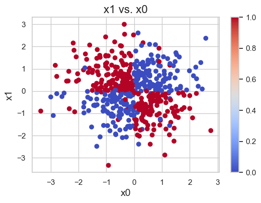

```python
plt.figure(figsize=(6, 4))
plt.scatter(train['x0'], train['x1'], c=train['y'], cmap='coolwarm')
plt.grid(True)
plt.xlabel('x0', fontsize=14)
plt.ylabel('x1', fontsize=14)
plt.title('x1 vs. x0', fontsize=16)
plt.colorbar()
```

## Data Preprocessing: Scaling the data

```python
# Feature scaling
scaler = StandardScaler()
X_train_scaled = scaler.fit_transform(X_train)
X_val_scaled = scaler.transform(X_val)
X_test_scaled = scaler.transform(X_test)
```

## Building the model

### Defining the Model

```python
def create_model(trial):
    # Hyperparameters to tune
    units = trial.suggest_int('units', config['model']['layers']['units']['min'],
                              config['model']['layers']['units']['max'],
                              step=config['model']['layers']['units']['step'])
    num_layers = trial.suggest_int('num_layers', config['model']['num_layers']['min'],
                                   config['model']['num_layers']['max'])
    activation = trial.suggest_categorical('activation', config['model']['layers']['activation'])
    optimizer_name = trial.suggest_categorical('optimizer', config['optimizer']['types'])
    learning_rate = trial.suggest_loguniform('learning_rate',
                                             config['optimizer']['learning_rate']['min'],
                                             config['optimizer']['learning_rate']['max'])
    l2_reg = trial.suggest_categorical('l2', config['model']['regularization']['l2'])
    dropout_rate = trial.suggest_categorical('dropout', config['model']['layers']['dropout'])

    # Build the model
    model = keras.Sequential()
    model.add(keras.Input(shape=(X_train_scaled.shape[1],)))

    for _ in range(num_layers):
        model.add(layers.Dense(units, activation=activation,
                               kernel_regularizer=regularizers.l2(l2_reg)))
        model.add(layers.Dropout(dropout_rate))

    model.add(layers.Dense(1, activation='sigmoid'))

    # Optimizer
    if optimizer_name == 'adam':
        optimizer = tf.keras.optimizers.Adam(learning_rate=learning_rate)
    elif optimizer_name == 'sgd':
        optimizer = tf.keras.optimizers.SGD(learning_rate=learning_rate)
    elif optimizer_name == 'adamw':
        optimizer = tf.keras.optimizers.AdamW(learning_rate=learning_rate)
    else:
        optimizer = tf.keras.optimizers.Adam(learning_rate=learning_rate)

    # Compile the model
    model.compile(optimizer=optimizer, loss='binary_crossentropy', metrics=['accuracy'])

    return model
```

### Setting up the learning rate scheduler

```python
# Setting up the learning rate scheduler
class WarmUpCosineDecayScheduler(Callback):
    def __init__(self, initial_lr, total_epochs, warmup_epochs=0, min_lr=1e-5, alpha=0.0):
        super(WarmUpCosineDecayScheduler, self).__init__()
        self.initial_lr = initial_lr
        self.total_epochs = total_epochs
        self.warmup_epochs = warmup_epochs
        self.min_lr = min_lr
        self.alpha = alpha  # Minimum learning rate as a fraction of initial_lr
        self.lrs = []

    def on_epoch_begin(self, epoch, logs=None):
        if epoch < self.warmup_epochs:
            lr = self.initial_lr * (epoch + 1) / self.warmup_epochs
        else:
            progress = (epoch - self.warmup_epochs) / (self.total_epochs - self.warmup_epochs)
            cosine_decay = 0.5 * (1 + np.cos(np.pi * progress))
            lr = self.min_lr + (self.initial_lr - self.min_lr) * cosine_decay
            lr = max(lr, self.alpha * self.initial_lr)  # Ensure lr doesn't go below alpha * initial_lr
        self.model .optimizer.lr.assign(lr)
        self.lrs.append(lr)
        print("DEBUG: learning rate appended to lrs")


def get_lr_scheduler(config):
    scheduler_type = config['learning_rate_scheduler']['type']
    if scheduler_type == 'warmup_cosine_decay':
        return WarmUpCosineDecayScheduler(
            warmup_epochs=int(config['learning_rate_scheduler']['warmup_epochs']),
            total_epochs=int(config['training']['epochs']),
            initial_lr=float(config['optimizer']['learning_rate']['min']),  # use the min as starting lr
            min_lr=float(config['learning_rate_scheduler']['min_lr']),
            alpha=float(config['learning_rate_scheduler']['alpha']),  # minimum lr will be alpha * initial_lr
            verbose=1
        )
    elif scheduler_type == 'reduce_lr_on_plateau':
        return tf.keras.callbacks.ReduceLROnPlateau(
            monitor='val_accuracy', factor=0.5, patience=5, min_lr=1e-6, verbose=1
        )
    else:
        return None

# Setting up the learning rate scheduler
class WarmUpCosineDecayScheduler(Callback):
    def __init__(self, initial_lr, total_epochs, warmup_epochs=0, min_lr=1e-5, alpha=0.0):
        super(WarmUpCosineDecayScheduler, self).__init__()
        self.initial_lr = initial_lr
        self.total_epochs = total_epochs
        self.warmup_epochs = warmup_epochs
        self.min_lr = min_lr
        self.alpha = alpha  # Minimum learning rate as a fraction of initial_lr
        self.lrs = []

    def on_epoch_begin(self, epoch, logs=None):
        if epoch < self.warmup_epochs:
            lr = self.initial_lr * (epoch + 1) / self.warmup_epochs
        else:
            progress = (epoch - self.warmup_epochs) / (self.total_epochs - self.warmup_epochs)
            cosine_decay = 0.5 * (1 + np.cos(np.pi * progress))
            lr = self.min_lr + (self.initial_lr - self.min_lr) * cosine_decay
            lr = max(lr, self.alpha * self.initial_lr)  # Ensure lr doesn't go below alpha * initial_lr
        self.model .optimizer.lr.assign(lr)
        self.lrs.append(lr)

def get_lr_scheduler(config):
    scheduler_type = config['learning_rate_scheduler']['type']
    if scheduler_type == 'warmup_cosine_decay':
        return WarmUpCosineDecayScheduler(
            warmup_epochs=int(config['learning_rate_scheduler']['warmup_epochs']),
            total_epochs=int(config['training']['epochs']),
            initial_lr=float(config['optimizer']['learning_rate']['min']),  # use the min as starting lr
            min_lr=float(config['learning_rate_scheduler']['min_lr']),
            alpha=float(config['learning_rate_scheduler']['alpha']),  # minimum lr will be alpha * initial_lr
            verbose=1
        )
    elif scheduler_type == 'reduce_lr_on_plateau':
        return tf.keras.callbacks.ReduceLROnPlateau(
            monitor='val_accuracy', factor=0.5, patience=5, min_lr=1e-6, verbose=1
        )
    else:
        return None
```

### Setting up callbacks

```python
def get_callbacks(config, trial=None):
    callbacks = []

    # Learning Rate Scheduler Callback
    lr_scheduler = WarmUpCosineDecayScheduler(
        initial_lr=config['optimizer']['learning_rate']['max'],
        total_epochs=config['training']['epochs'],
        warmup_epochs=config['learning_rate_scheduler']['warmup_epochs'],
        min_lr=config['learning_rate_scheduler']['min_lr'],
        alpha=config['learning_rate_scheduler']['alpha']
    )
    callbacks.append(lr_scheduler)

    # Early Stopping Callback
    early_stopping = tf.keras.callbacks.EarlyStopping(
        monitor='val_accuracy',
        patience=config['training']['early_stopping_patience'],
        restore_best_weights=True,
        mode='max',
        verbose=1
    )
    callbacks.append(early_stopping)

    # Optuna Pruning Callback (if trial is provided)
    if trial is not None:
        pruning_callback = TFKerasPruningCallback(trial, monitor='val_accuracy')
        callbacks.append(pruning_callback)

    return callbacks
```

## Training model

### *With* learning rate scheduler and early stopping

#### Defining Optuna objective

```python
def objective(trial):
    # Create the model with the current hyperparameters
    model = create_model(trial)

    # Get callbacks
    callbacks = get_callbacks(config, trial)

    # Train the model
    history = model.fit(
        X_train_scaled, y_train,
        validation_data=(X_val_scaled, y_val),
        epochs=config['training']['epochs'],
        batch_size=32,
        callbacks=[callbacks],
        verbose=1
    )

    # Get the best validation accuracy of the training epochs
    val_accuracy = max(history.history['val_accuracy'])

    return val_accuracy
```

#### Running the Optuna study

```python
import optuna

study = optuna.create_study(direction='maximize', study_name='SkyNet_Decryption')
study.optimize(objective, n_trials=10)
```

```
[I 2024-10-17 03:38:04,359] A new study created in memory with name: SkyNet_Decryption
```

```
... (shortened output)
Epoch 68: early stopping
```

```
[I 2024-10-17 03:38:18,938] Trial 0 finished with value: 0.949999988079071 and parameters: {'units': 20, 'num_layers': 4, 'activation': 'tanh', 'optimizer': 'adam', 'learning_rate': 0.005230187801820017, 'l2': 0.001, 'dropout': 0.1}. Best is trial 0 with value: 0.949999988079071.
```

```
... (shortened output)
Epoch 83: early stopping
```

```
[I 2024-10-17 03:38:32,357] Trial 1 finished with value: 0.9300000071525574 and parameters: {'units': 24, 'num_layers': 3, 'activation': 'relu', 'optimizer': 'adam', 'learning_rate': 0.00019669683438871502, 'l2': 0.0001, 'dropout': 0.2}. Best is trial 0 with value: 0.949999988079071.
```

```
... (shortened output)
Epoch 46: early stopping
```

```
[I 2024-10-17 03:38:42,264] Trial 2 finished with value: 0.9399999976158142 and parameters: {'units': 32, 'num_layers': 4, 'activation': 'relu', 'optimizer': 'adam', 'learning_rate': 2.653638431676812e-05, 'l2': 0.0, 'dropout': 0.2}. Best is trial 0 with value: 0.949999988079071.
```

```
... (shortened output)
Epoch 57: early stopping
```

```
[I 2024-10-17 03:38:53,575] Trial 3 finished with value: 0.949999988079071 and parameters: {'units': 24, 'num_layers': 4, 'activation': 'relu', 'optimizer': 'adam', 'learning_rate': 0.0006609299462532911, 'l2': 0.0, 'dropout': 0.1}. Best is trial 0 with value: 0.949999988079071.
```

```
... (shortened output)
Epoch 98: early stopping
```

```
[I 2024-10-17 03:39:08,791] Trial 4 finished with value: 0.949999988079071 and parameters: {'units': 32, 'num_layers': 4, 'activation': 'relu', 'optimizer': 'adam', 'learning_rate': 0.002007034765299749, 'l2': 0.0, 'dropout': 0.2}. Best is trial 0 with value: 0.949999988079071.
```

```
[I 2024-10-17 03:39:12,263] Trial 5 pruned. Trial was pruned at epoch 0.
```

```
[I 2024-10-17 03:39:14,962] Trial 6 pruned. Trial was pruned at epoch 1.
```

```
[I 2024-10-17 03:39:17,756] Trial 7 pruned. Trial was pruned at epoch 0.
```

```
[I 2024-10-17 03:39:20,992] Trial 8 pruned. Trial was pruned at epoch 0.
```

```
[I 2024-10-17 03:39:23,351] Trial 9 pruned. Trial was pruned at epoch 0.
```

#### Retrieve Best Hyperparameters and Train Final Model

```python
print("Number of finished trials: {}".format(len(study.trials)))
print("Best trial:")
trial = study.best_trial

print("  Validation Accuracy: {:.4f}".format(trial.value))

print("  Best hyperparameters: ")
for key, value in trial.params.items():
    print("    {}: {}".format(key, value))
```

```
Number of finished trials: 10
Best trial:
  Validation Accuracy: 0.9500
  Best hyperparameters:
    units: 20
    num_layers: 4
    activation: tanh
    optimizer: adam
    learning_rate: 0.005230187801820017
    l2: 0.001
    dropout: 0.1
```

```python
# Build the model with the best hyperparameters
best_model = create_model(trial)

callbacks = get_callbacks(config, trial)

# For the final training, we will allow for more patience, increase the epochs, and reduce the learning rate
config['training']['epochs'] = 500
config['training']['early_stopping_patience'] = 200

# Learning Rate Scheduler
lr_scheduler = WarmUpCosineDecayScheduler(
    initial_lr=config['optimizer']['learning_rate']['max'],
    total_epochs=config['training']['epochs'],
    warmup_epochs=config['learning_rate_scheduler']['warmup_epochs'],
    min_lr=config['learning_rate_scheduler']['min_lr'],
    alpha=config['learning_rate_scheduler']['alpha']
)

# Early Stopping
early_stopping = keras.callbacks.EarlyStopping(
    monitor='val_accuracy',
    patience=config['training']['early_stopping_patience'],
    restore_best_weights=True,
    mode='max'
)

# Train the model
history = best_model.fit(
    X_train_scaled, y_train,
    validation_data=(X_val_scaled, y_val),
    epochs=config['training']['epochs'],
    batch_size=32,
    callbacks=callbacks,
    verbose=1
)
```

```
... (shortened output)
Epoch 68: early stopping
```

#### Save the best final model

```python
# Save the final model
final_model_path = os.path.join(model_path, 'task1', 'final_model.keras')
best_model.save(final_model_path)
print(f"Final model saved at {final_model_path}")
```

```
Final model saved at ../models/task1/final_model.keras
```

#### Evaluate model on test data

```python
# Evaluate on test data
test_loss, test_accuracy = best_model.evaluate(X_test_scaled, y_test, verbose=0)
print(f"Test Accuracy: {test_accuracy:.4f}")
```

```
Test Accuracy: 0.9200
```

### Comparison to model *without* scheduler and early stopping

#### Train the model

```python
# Train the model without learning rate scheduler and early stopping
history_no_scheduler = best_model.fit(
    X_train_scaled, y_train,
    validation_data=(X_val_scaled, y_val),
    epochs=config['training']['epochs'],
    batch_size=32,
    verbose=1
)
```

```
... (shortened output)
```

### Evaluate on test data

```python
# Evaluate on test data
test_loss_no_scheduler, test_accuracy_no_scheduler = best_model.evaluate(X_test_scaled, y_test, verbose=0)
print(f"Test Accuracy without Scheduler: {test_accuracy_no_scheduler:.4f}")
```

```
Test Accuracy without Scheduler: 0.9260
```

### Compare results with and without learning rate scheduler

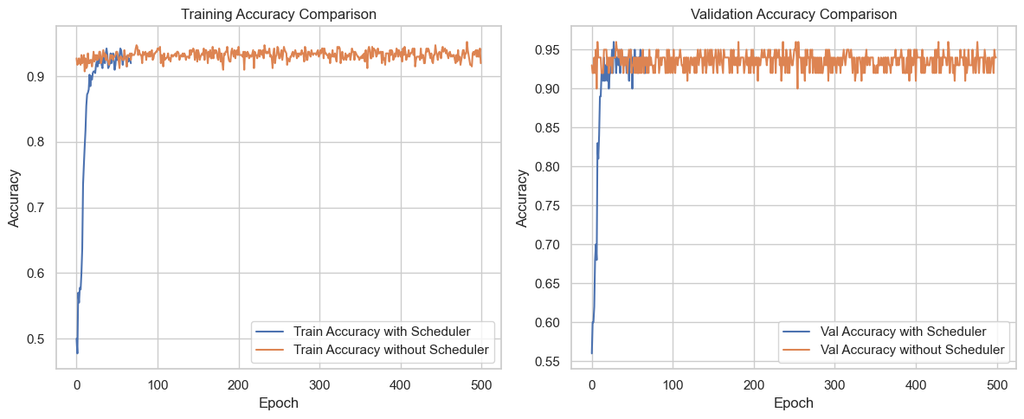

```python
# Plot training & validation accuracy values for both models
plt.figure(figsize=(12, 5))

plt.subplot(1, 2, 1)
plt.plot(history.history['accuracy'], label='Train Accuracy with Scheduler')
plt.plot(history_no_scheduler.history['accuracy'], label='Train Accuracy without Scheduler')
plt.title('Training Accuracy Comparison')
plt.ylabel('Accuracy')
plt.xlabel('Epoch')
plt.legend(loc='lower right')

plt.subplot(1, 2, 2)
plt.plot(history.history['val_accuracy'], label='Val Accuracy with Scheduler')
plt.plot(history_no_scheduler.history['val_accuracy'], label='Val Accuracy without Scheduler')
plt.title('Validation Accuracy Comparison')
plt.ylabel('Accuracy')
plt.xlabel('Epoch')
plt.legend(loc='lower right')

plt.tight_layout()
plt.show()
```

The blue line stopping so early indicates that the early stopping hyperparameter might be tuned a little too low? Or, since the validation accuracy of the training without early stopping doesnt seem to improve much across the epochs, perhaps there simply are way too many epochs.

## Visualization

### Visualize the Model Architecture

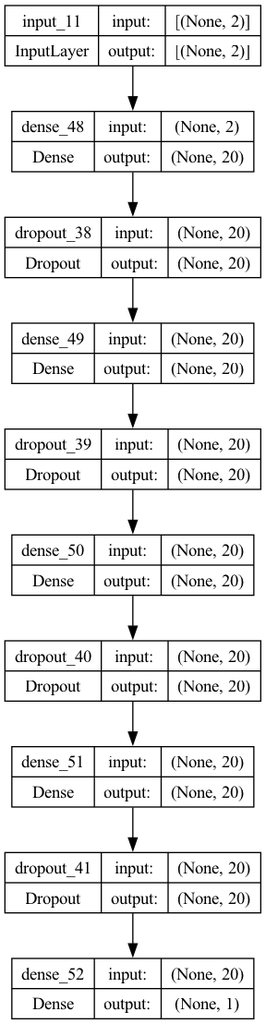

```python
# Visualize the updated model architecture
model_architecture_path = os.path.join(model_path, 'model_architecture.png')

plot_model(
    best_model,
    to_file=model_architecture_path,
    show_shapes=True,
    show_layer_names=True,
    expand_nested=True
)
```

### Visualize Decision Boundary

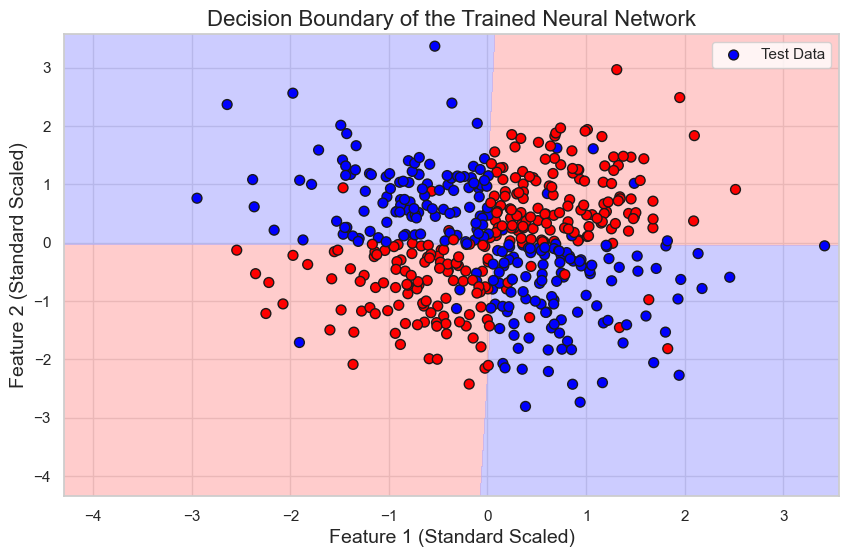

```python
# Visualization: Decision Boundary

from matplotlib.colors import ListedColormap

# Define the range of the grid
x_min, x_max = X_train_scaled[:, 0].min() - 1, X_train_scaled[:, 0].max() + 1
y_min, y_max = X_train_scaled[:, 1].min() - 1, X_train_scaled[:, 1].max() + 1

# Define the mesh grid step size
h = 0.01  # Smaller values for higher resolution

# Generate grid points
xx, yy = np.meshgrid(np.arange(x_min, x_max, h),
                     np.arange(y_min, y_max, h))

# Flatten the grid to pass into the model
grid = np.c_[xx.ravel(), yy.ravel()]

# Predict probabilities for each point in the grid
Z = best_model.predict(grid, verbose=0)
Z = Z.reshape(xx.shape)

# Define the contour levels for binary classification
levels = [0.0, 0.5, 1.0]  # Two regions: <0.5 and >=0.5

# Create a color map
cmap_light = ListedColormap(['#FFAAAA', '#AAAAFF'])
cmap_bold = ListedColormap(['#FF0000', '#0000FF'])

plt.figure(figsize=(10, 6))

# Plot the decision boundary by filling regions
plt.contourf(xx, yy, Z, levels=levels, cmap=cmap_light, alpha=0.6)

# Plot the actual test data points
plt.scatter(X_test_scaled[:, 0], X_test_scaled[:, 1], c=y_test, cmap=cmap_bold,
            edgecolor='k', s=50, label='Test Data')

plt.title('Decision Boundary of the Trained Neural Network', fontsize=16)
plt.xlabel('Feature 1 (Standard Scaled)', fontsize=14)
plt.ylabel('Feature 2 (Standard Scaled)', fontsize=14)
plt.legend()
plt.grid(True)
plt.show()
```

### Visualize Model Accuracy with and without scheduler

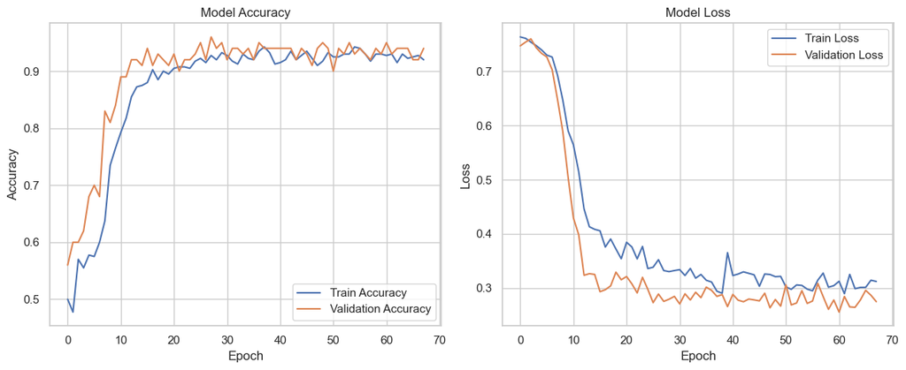

```python
# Plot training & validation accuracy values
plt.figure(figsize=(12, 5))

plt.subplot(1, 2, 1)
plt.plot(history.history['accuracy'], label='Train Accuracy')
plt.plot(history.history['val_accuracy'], label='Validation Accuracy')
plt.title('Model Accuracy')
plt.ylabel('Accuracy')
plt.xlabel('Epoch')
plt.legend(loc='lower right')

# Plot training & validation loss values
plt.subplot(1, 2, 2)
plt.plot(history.history['loss'], label='Train Loss')
plt.plot(history.history['val_loss'], label='Validation Loss')
plt.title('Model Loss')
plt.ylabel('Loss')
plt.xlabel('Epoch')
plt.legend(loc='upper right')

plt.tight_layout()
plt.show()
```

### Visualize Learning Rate Dynamics of the Scheduler

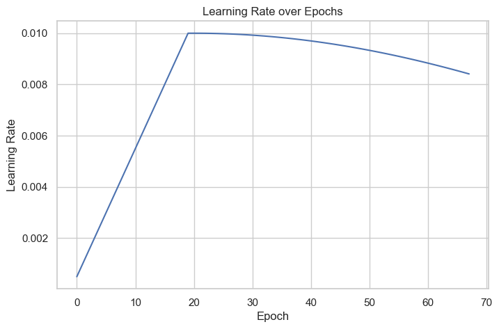

```python
# Extract learning rate values
for cb in callbacks:
    if isinstance(cb, WarmUpCosineDecayScheduler):
        lrs = cb.lrs
        break

# Plot learning rate over epochs
plt.figure(figsize=(8, 5))
plt.plot(lrs)
plt.title('Learning Rate over Epochs')
plt.xlabel('Epoch')
plt.ylabel('Learning Rate')
plt.grid(True)
plt.show()
```

## Ablation Study Using Optuna Visualization

### General overview

```python
# Print the number of finished trials
print(f"Number of finished trials: {len(study.trials)}")

# Print the best trial
print("Best trial:")
trial = study.best_trial

print(f"  Value: {trial.value}")
print("  Params: ")
for key, value in trial.params.items():
    print(f"    {key}: {value}")

print()

# Print all trials
for i, t in enumerate(study.trials):
    print(f"Trial {i}:")
    print(f"  Value: {t.value}")
    print("  Params: ")
    for key, value in t.params.items():
        print(f"    {key}: {value}")
```

```
Number of finished trials: 10
Best trial:
  Value: 0.949999988079071
  Params:
    units: 20
    num_layers: 4
    activation: tanh
    optimizer: adam
    learning_rate: 0.005230187801820017
    l2: 0.001
    dropout: 0.1

Trial 0:
  Value: 0.949999988079071
  Params:
    units: 20
    num_layers: 4
    activation: tanh
    optimizer: adam
    learning_rate: 0.005230187801820017
    l2: 0.001
    dropout: 0.1
Trial 1:
... (shortened output)
```

### Diagram of Hyperparameter Importance

```python
param_importances = optuna.importance.get_param_importances(study)

fig = optuna.visualization.plot_param_importances(study)
fig.show()
```

[output not shown]

### Diagram of Optimization History

```python
fig = optuna.visualization.plot_optimization_history(study)
fig.show()
```

[output not shown]

### Parallel Coordinate Plot

```python
fig = optuna.visualization.plot_parallel_coordinate(study)
fig.show()
```

[output not shown]

## Discussion

- **How did you achieve the reproducibility of the results?**

To ensure reproducible results, a function `set_seed` was defined and invoked at the beginning of the notebook to set seeds for `numpy`, `random`, and TensorFlow. Additionally, the `PYTHONHASHSEED` environment variable was set. This was not, however, enough, because the test accuracies fluctuated slightly between runs. I saw on Piazz that others struggled with the same problem.

- **Visualize the network's architecture and decision boundary.**

Please see the diagram and plot in the Visualization-section of the notebook.

- **Which optimizer did you choose? Discuss the differences between the SGD and Adam optimizers.**

Adam optimizer was selected for its adaptive learning rate capabilities. SGD requires manual tuning of learning rates and may converge slower, while Adam automatically adjusts learning rates, generally providing faster convergence.

- **Visualize the learning rate dynamics. Did the learning rate scheduling improve performance? Why or why not?**

- **Conduct an ablation study of each architectural and optimization choice concerning test accuracy.**

Please see the ablation study section.

# Mission 2: Unsupervised

# 📶📡🛰️🤳 Mission 2.2: Locate the AI Servers

### 🌐 The Discovery

The NTNU Intelligence team has intercepted encrypted documentation that potentially reveals the locations of AI-compromised servers within Trondheim. Our analysts believe the data contains information about these servers' locations.

However, the number of servers and their exact positions remain unknown. To execute a strategic response, we need to understand the intercepted data and pinpoint the main AI servers.

We have also discovered a vulnerability in the AI's security: it has deployed a clustering verification feature on Kaggle. We can exploit this backdoor to validate our clustering hypotheses.

### 🎯 Your Mission

Identify the number of hidden servers (clusters) in the dataset. Assign cluster labels to each row in the original dataset and validate your clustering solution on Kaggle. When achieved the perfect clustering accuracy, find the precise locations of these servers (clusters).

### 🧠 The Challenge

1. **Large Dataset**: The intercepted data file contains numerous features, making direct manipulation and clustering difficult. Applying dimensionality reduction techniques could help reveal patterns.
2. **Unsupervised Learning**: No target labels are provided, so you must identify patterns based solely on the dataset's features.
3. **Data Obfuscation**: The AI has obfuscated the data, making it difficult to discern its true structure. You must effectively manipulate the data to visually identify server locations.

### 🚀 Your Tools

- The intercepted AI dataset.
- Skills in feature engineering, data manipulation, and visualization.
- Clustering algorithms (e.g., KMeans, DBSCAN, Birch, Agglomerative Clustering, etc.) — [Clustering in Scikit-Learn](https://scikit-learn.org/stable/modules/clustering.html)
- Dimensionality reduction techniques (e.g., PCA, t-SNE, Isomap, UMAP, etc.)
- Kaggle competition platform with a daily submission limit of 50 attempts (~30 days * 50 submissions = 1500 total attempts per student).

> Note: Kaggle competition link — [Kaggle Competition](https://www.kaggle.com/t/6610d6c6ba314eac9ead0b7a47695700)

### 📊 Formal Requirements

1. **Achieve 100% Clustering Accuracy** on Kaggle.

> Note: The only way to check whether your clustering is correct is to submit it to Kaggle. We do not give you the clusters directly.
2. **Discussion Questions**:
   - **Dimensionality Reduction**: Which dimensionality reduction methods helped you determine the correct number of clusters? Why did some methods work better than others? Explain the differences between PCA, t-SNE, and UMAP.
   - **Clustering Approach**: Which clustering algorithm and hyperparameters did you use? Discuss the differences between algorithms like KMeans and DBSCAN.
   - **Server Locations**: Identify the server locations. List the specific facilities in Trondheim and explain how you deduced their locations.
   - **Data Type Analysis**: What is the hidden data type in the dataset? How does this information influence feature extraction for clustering? Can it explain why some dimensionality reduction algorithms are more effective?
   - **Advanced Task (Optional)**: Extract features using modern pre-trained neural networks for this data type. Apply dimensionality reduction and clustering algorithms to the extracted features.

## Setup and configuration

*Recommended configuration in Vertex, because of large dataset 32GB+ of RAM*

### Define file paths

```python
# Define model save path
model_path_2 = os.path.join(model_path, 'task2')
```

## Data loading and preprocessing

### Load dataset

```python
data_path = os.path.join(root_path, 'data', 'raw', 'unsupervised_data.csv')
df = pd.read_csv(data_path)
```

```python
# Reset index to create 'ID' column
df.reset_index(drop=False, inplace=True)
df.rename(columns={'index': 'ID'}, inplace=True)
```

```python
print(df.columns)
```

```
Index(['ID', 'col_9858', 'col_2932', 'col_12843', 'col_5156', 'col_2677',
       'col_9520', 'col_291', 'col_14843', 'col_10287',
       ...
       'col_6265', 'col_5734', 'col_11284', 'col_11964', 'col_5191',
       'col_13418', 'col_5390', 'col_860', 'col_15795', 'col_7270'],
      dtype='object', length=16385)
```

```python
print(df.info())
```

```
<class 'pandas.core.frame.DataFrame'>
RangeIndex: 4000 entries, 0 to 3999
Columns: 16385 entries, ID to col_7270
dtypes: float64(16384), int64(1)
memory usage: 500.0 MB
None
```

## Hypothesis of image data

From the loading of the dataset, we see that there are 128*128=16 384 columns, which suggests that each row of the dataset represents images of some sort (also leveraging some hints given at Piazza). We can try to reshape a row to test the hypothesis.

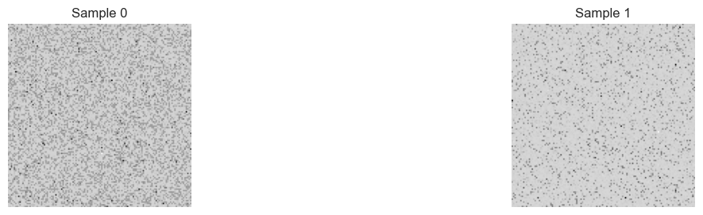

```python
fig, axes = plt.subplots(1, 2, figsize=(15, 3))
for i, ax in enumerate(axes):
    sample_image = df.iloc[i, 1:].values.reshape(128, 128)
    ax.imshow(sample_image, cmap='gray')
    ax.axis('off')
    ax.set_title(f'Sample {i}')
plt.show()
```

That doesn't make much sense yet. However, we have seen in the data that the column names are scrambled up. It would make sense, since this may represent image data, that the columns should be sorted.

```python
# Extract column names and sort them based on the numerical part after the underscore
sorted_columns = sorted(
    [col for col in df.columns if col != 'ID'],
    key=lambda col: int(col.split('_')[1]) if '_' in col else 0
)

# Use the sorted column names to get the sorted data
sorted_df = df[['ID'] + sorted_columns]
```

With the columns now sorted, we can try to visualize the two first rows again:

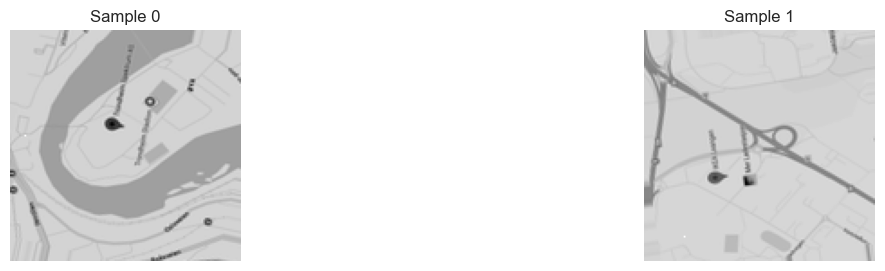

```python
fig, axes = plt.subplots(1, 2, figsize=(15, 3))
for i, ax in enumerate(axes):
    sample_image = sorted_df.iloc[i, 1:].values.reshape(128, 128)
    ax.imshow(sample_image, cmap='gray')
    ax.axis('off')
    ax.set_title(f'Sample {i}')
plt.show()
```

Now things look much better. It seems like images pulled straight out of Google Maps. Obviously it would be a little dreary to iterate through all of the images to deduce the satelite locations of each. Perhaps we can combine all the rows of images into one big map?

But then: how many rows are there? 4000... 200 * 20?

Perhaps we can rather generate some more images and see if we can trace the river?

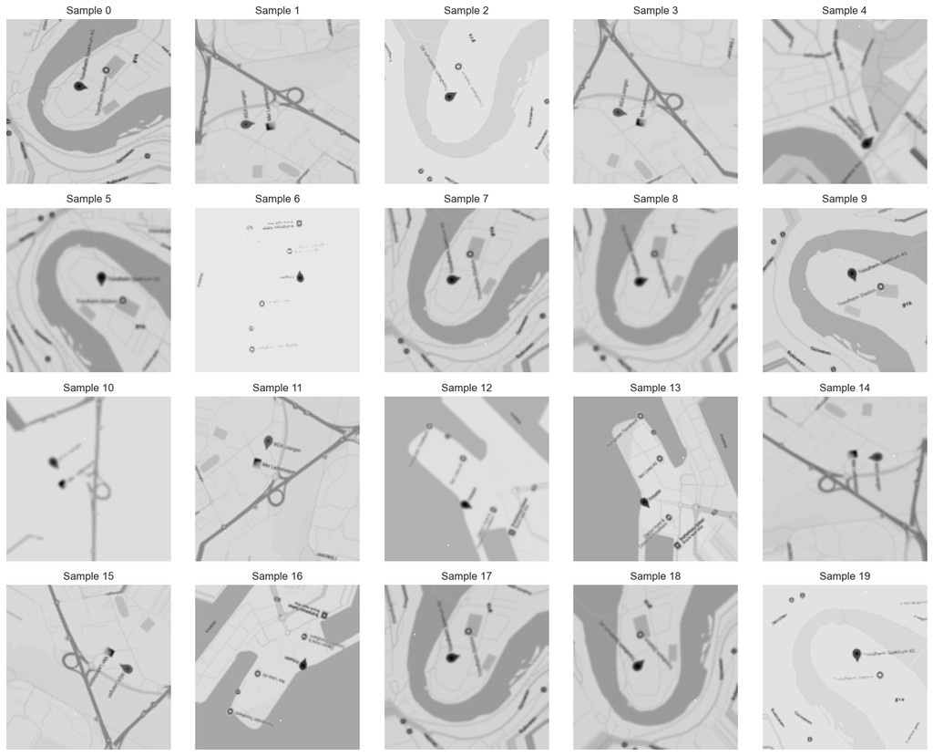

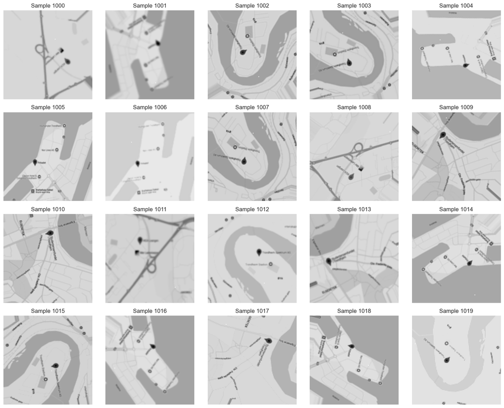

```python
fig, axes = plt.subplots(4, 5, figsize=(15, 12))
for i, ax in enumerate(axes.flat):
    sample_image = sorted_df.iloc[i, 1:].values.reshape(128, 128)
    ax.imshow(sample_image, cmap='gray')
    ax.axis('off')
    ax.set_title(f'Sample {i}')
plt.tight_layout()
plt.show()

# Try a different subset of the data
fig, axes = plt.subplots(4, 5, figsize=(15, 12))

# Loop over the range 1000 to 1020
for i, ax in zip(range(1000, 1020), axes.flat):
    sample_image = sorted_df.iloc[i, 1:].values.reshape(128, 128)
    ax.imshow(sample_image, cmap='gray')
    ax.axis('off')
    ax.set_title(f'Sample {i}')

plt.tight_layout()
plt.show()
```

It turns out that there are just repeating images with small variations. We will come back to this once we know how many clusters we have to look for.

## Feature Reduction

Now that we have determined that the dataset consists of images, that should guide our choice of feature reduction technique. Amongst PCA, t-SNE, and UMAP, UMAP is the clearly best suited. While PCA is a linear method and thus does not work for images, typically nonlinear, UMAP handles nonlinearity with computational efficiency. t-SNE is much more costly computationally for large datasets and also distorts global relationships. Another factor in going ahead with UMAP is that it manages to preserve the spatial context of the data and respect the internal geometry of the image.

We will proceed with UMAP as the selected feature reduction technique and begin with visualizing it with some different hyperparameters

```
/Users/folkejernbert/Library/Mobile Documents/com~apple~CloudDocs/Skole/Høst-24/tdt4172/Assignment2/tdt4172-assignment2/lib/python3.10/site-packages/umap/umap_.py:1945: UserWarning:

n_jobs value 1 overridden to 1 by setting random_state. Use no seed for parallelism.
```

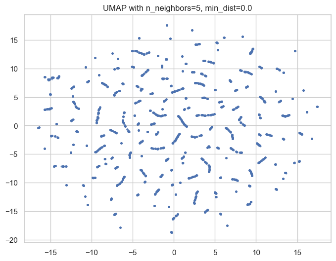

```
/Users/folkejernbert/Library/Mobile Documents/com~apple~CloudDocs/Skole/Høst-24/tdt4172/Assignment2/tdt4172-assignment2/lib/python3.10/site-packages/umap/umap_.py:1945: UserWarning:

n_jobs value 1 overridden to 1 by setting random_state. Use no seed for parallelism.
```

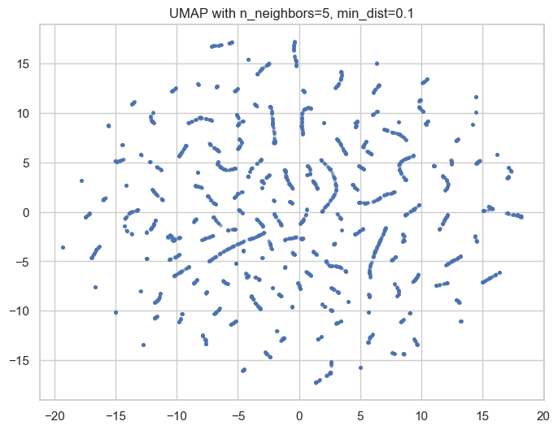

```
/Users/folkejernbert/Library/Mobile Documents/com~apple~CloudDocs/Skole/Høst-24/tdt4172/Assignment2/tdt4172-assignment2/lib/python3.10/site-packages/umap/umap_.py:1945: UserWarning:

n_jobs value 1 overridden to 1 by setting random_state. Use no seed for parallelism.
```

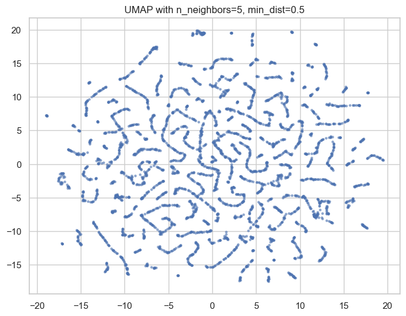

```
/Users/folkejernbert/Library/Mobile Documents/com~apple~CloudDocs/Skole/Høst-24/tdt4172/Assignment2/tdt4172-assignment2/lib/python3.10/site-packages/umap/umap_.py:1945: UserWarning:

n_jobs value 1 overridden to 1 by setting random_state. Use no seed for parallelism.
```

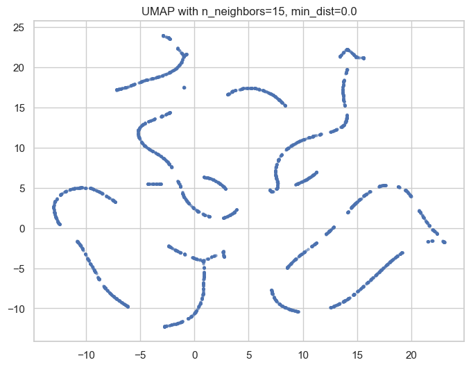

```
/Users/folkejernbert/Library/Mobile Documents/com~apple~CloudDocs/Skole/Høst-24/tdt4172/Assignment2/tdt4172-assignment2/lib/python3.10/site-packages/umap/umap_.py:1945: UserWarning:

n_jobs value 1 overridden to 1 by setting random_state. Use no seed for parallelism.
```

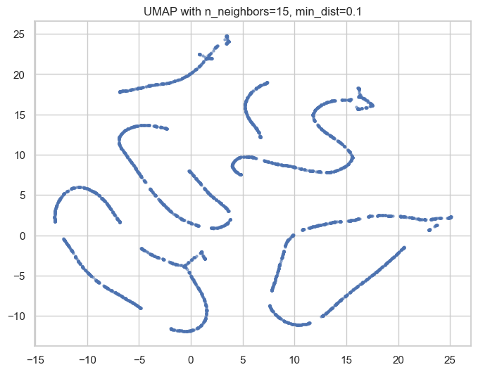

```
/Users/folkejernbert/Library/Mobile Documents/com~apple~CloudDocs/Skole/Høst-24/tdt4172/Assignment2/tdt4172-assignment2/lib/python3.10/site-packages/umap/umap_.py:1945: UserWarning:

n_jobs value 1 overridden to 1 by setting random_state. Use no seed for parallelism.
```

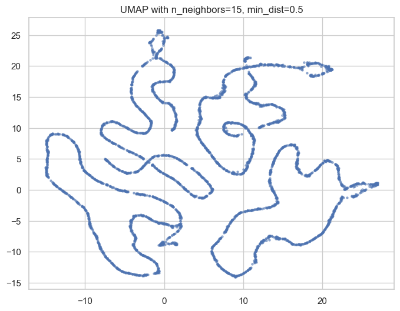

```
/Users/folkejernbert/Library/Mobile Documents/com~apple~CloudDocs/Skole/Høst-24/tdt4172/Assignment2/tdt4172-assignment2/lib/python3.10/site-packages/umap/umap_.py:1945: UserWarning:

n_jobs value 1 overridden to 1 by setting random_state. Use no seed for parallelism.
```

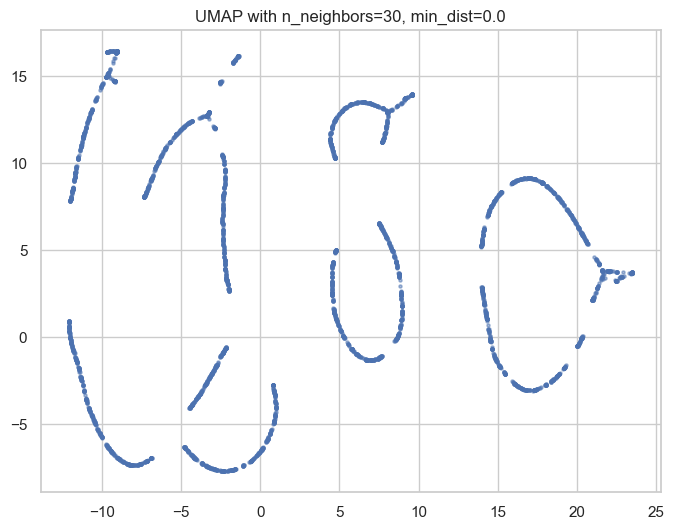

```
/Users/folkejernbert/Library/Mobile Documents/com~apple~CloudDocs/Skole/Høst-24/tdt4172/Assignment2/tdt4172-assignment2/lib/python3.10/site-packages/umap/umap_.py:1945: UserWarning:

n_jobs value 1 overridden to 1 by setting random_state. Use no seed for parallelism.
```

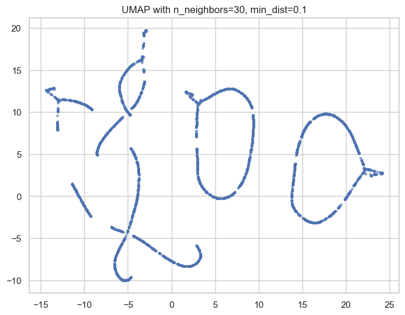

```
/Users/folkejernbert/Library/Mobile Documents/com~apple~CloudDocs/Skole/Høst-24/tdt4172/Assignment2/tdt4172-assignment2/lib/python3.10/site-packages/umap/umap_.py:1945: UserWarning:

n_jobs value 1 overridden to 1 by setting random_state. Use no seed for parallelism.
```

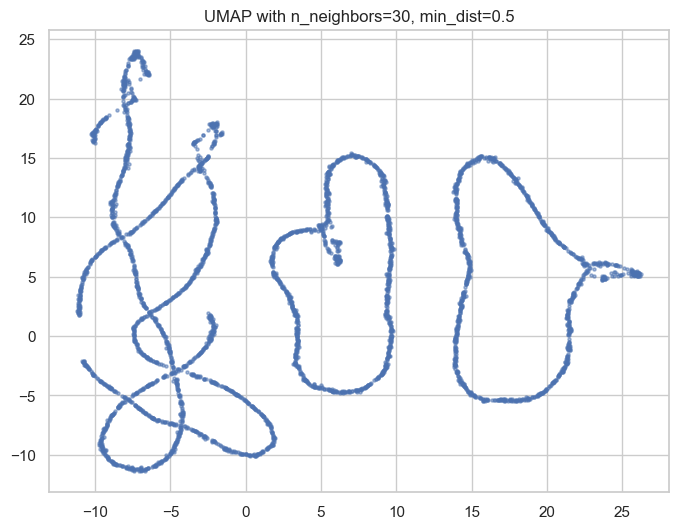

```python
import umap.umap_ as umap

n_neighbors_list = [5, 15, 30]
min_dist_list = [0.0, 0.1, 0.5]

for n_neighbors in n_neighbors_list:
    for min_dist in min_dist_list:
        umap_reducer = umap.UMAP(n_neighbors=n_neighbors, min_dist=min_dist, random_state=42)
        X_umap = umap_reducer.fit_transform(sorted_df.iloc[:, 1:])
        plt.figure(figsize=(8, 6))
        plt.scatter(X_umap[:, 0], X_umap[:, 1], s=5, alpha=0.5)
        plt.title(f'UMAP with n_neighbors={n_neighbors}, min_dist={min_dist}')
        plt.show()
```

Let's interpret the plots we have generated. Number of neighbours controls how UMAP balances local and global structure, such that a low number of neighbours focuses on local neighborhoods, whereas a higher number emphasizes larger-scale structure. From the plots we generated, we see that as we increase the number of neighbours, we go from a very scattered feature reduction to something more continuous. Min_distance controls how tightly clustered the points are.

We might consider what we are actually trying to cluster here, namely the locations of malicious AI servers in Trondheim. Considering that there might be some noise in the dataset, an idea would be to preserve a tight clustering so as to clearly delineate the different data points which in reality are the same server. At the same time a higher value of number of neighbours would give us a sense of the global structure of the server locations throughout the city, and this would be desirable.

## Clustering

As we can see from the outputs in the former section, the UMAP Feature Reduction produces clusters, we immediately notice that the clusters are not of a spherical shape, which immediately precludes KMeans. The shapes are rather of arbitrary shapes, and this leads us to think that this might be a job for DBScan.

To find the optimal combination of feature reduction hyperparameters and clustering, we will use an Optuna study, at each trial generating a silhouette score as well as a Kaggle submission CSV. Doing that will make it easy to try and fail until we find the one that generates the 100% accuracy.

### Function for generating submission file

```python
import pandas as pd
import os
import datetime

def generate_submission(cluster_labels, ids, hyperparams, silhouette_score, model_save_path):
    """
    Generates a Kaggle submission CSV file with hyperparameters and silhouette score in the filename.

    Parameters:
    - cluster_labels (array-like): Cluster labels assigned by the clustering algorithm.
    - ids (array-like): Original IDs from the dataset.
    - hyperparams (dict): Dictionary of hyperparameters used (e.g., UMAP and DBSCAN parameters).
    - silhouette_score (float): Silhouette score of the clustering.
    - model_save_path (str): Path where the submission file will be saved.

    Returns:
    - submission_file_path (str): Path to the saved submission CSV file.
    """
    # Create the submission DataFrame
    submission = pd.DataFrame({
        'ID': ids,
        'cluster': cluster_labels
    })

    # Ensure 'cluster' is of integer type
    submission['cluster'] = submission['cluster'].astype(int)

    # Get current timestamp
    timestamp = datetime.datetime.now().strftime("%Y%m%d_%H%M%S")

    # Construct filename with hyperparameters and silhouette score
    filename = (
        f"submission_{timestamp}_umap_nn{hyperparams['n_neighbors']}_md{hyperparams['min_dist']}"
        f"_dbscan_eps{hyperparams['eps']:.2f}_ms{hyperparams['min_samples']}"
        f"_sil{silhouette_score:.4f}.csv"
    )

    # Full path to save the submission file
    submission_file_path = os.path.join(model_save_path, filename)

    # Save the submission CSV
    submission.to_csv(submission_file_path, index=False)

    print(f"Submission file saved to: {submission_file_path}")

    return submission_file_path
```

### Generating some DBScan Clusterings

Before we run the Optuna Search, we should try out some different hyperparameters for the DBScan to get some ballpark figures for the search space we should try out.

We'll choose a baseline UMAP of min distance = 0.1 and number of neighbours = 30.

#### UMAP Dimensionality Baseline

```python
# Prepare the data for UMAP (exclude 'ID' column)
X = sorted_df.iloc[:, 1:].values

# Apply UMAP with the optimal hyperparameters
umap_reducer = umap.UMAP(n_neighbors=30, min_dist=0.1, random_state=42)
X_umap = umap_reducer.fit_transform(X)
```

```
/Users/folkejernbert/Library/Mobile Documents/com~apple~CloudDocs/Skole/Høst-24/tdt4172/Assignment2/tdt4172-assignment2/lib/python3.10/site-packages/umap/umap_.py:1945: UserWarning:

n_jobs value 1 overridden to 1 by setting random_state. Use no seed for parallelism.
```

#### Testing out some DBScan hyperparameters

```python
eps_list = [1.0, 3.0, 5.0]
min_samples_list = [5, 15, 20]

for eps in eps_list:
    for min_samples in min_samples_list:
        dbscan = DBSCAN(eps=eps, min_samples=min_samples)
        cluster_labels = dbscan.fit_predict(X_umap)
        n_clusters = len(np.unique(cluster_labels))
        silhouette = silhouette_score(X_umap, cluster_labels)
        print(f"DBSCAN with eps={eps}, min_samples={min_samples}:")
        print(f"Number of clusters: {n_clusters}")
        print(f"Silhouette score: {silhouette:.4f}")
        print()
```

```
DBSCAN with eps=1.0, min_samples=5:
Number of clusters: 6
Silhouette score: 0.4147

DBSCAN with eps=1.0, min_samples=15:
Number of clusters: 6
Silhouette score: 0.4147

DBSCAN with eps=1.0, min_samples=20:
Number of clusters: 8
Silhouette score: 0.3469

DBSCAN with eps=3.0, min_samples=5:
Number of clusters: 5
Silhouette score: 0.4518

DBSCAN with eps=3.0, min_samples=15:
Number of clusters: 5
Silhouette score: 0.4518

DBSCAN with eps=3.0, min_samples=20:
Number of clusters: 5
Silhouette score: 0.4518

DBSCAN with eps=5.0, min_samples=5:
Number of clusters: 2
Silhouette score: 0.4348

DBSCAN with eps=5.0, min_samples=15:
Number of clusters: 2
Silhouette score: 0.4348

DBSCAN with eps=5.0, min_samples=20:
Number of clusters: 2
Silhouette score: 0.4348
```

From this quick study, it seems that the silhouette score decreases as we increase the number of clusters above a some 15 samples. Since this runs so quickly, we can further tune it a little more before sending it to Optuna.

```python
eps_list = [2.5, 3.0, 3.5, 4.0]
min_samples_list = [8, 10, 12]

for eps in eps_list:
    for min_samples in min_samples_list:
        dbscan = DBSCAN(eps=eps, min_samples=min_samples)
        cluster_labels = dbscan.fit_predict(X_umap)
        n_clusters = len(np.unique(cluster_labels))
        silhouette = silhouette_score(X_umap, cluster_labels)
        print(f"DBSCAN with eps={eps}, min_samples={min_samples}:")
        print(f"Number of clusters: {n_clusters}")
        print(f"Silhouette score: {silhouette:.4f}")
        print()
```

```
DBSCAN with eps=2.5, min_samples=8:
Number of clusters: 6
Silhouette score: 0.4147

DBSCAN with eps=2.5, min_samples=10:
Number of clusters: 6
Silhouette score: 0.4147

DBSCAN with eps=2.5, min_samples=12:
Number of clusters: 6
Silhouette score: 0.4147

DBSCAN with eps=3.0, min_samples=8:
Number of clusters: 5
Silhouette score: 0.4518

DBSCAN with eps=3.0, min_samples=10:
Number of clusters: 5
Silhouette score: 0.4518

DBSCAN with eps=3.0, min_samples=12:
Number of clusters: 5
Silhouette score: 0.4518

DBSCAN with eps=3.5, min_samples=8:
Number of clusters: 3
Silhouette score: 0.3647

DBSCAN with eps=3.5, min_samples=10:
Number of clusters: 3
Silhouette score: 0.3647

DBSCAN with eps=3.5, min_samples=12:
Number of clusters: 3
Silhouette score: 0.3647

DBSCAN with eps=4.0, min_samples=8:
Number of clusters: 3
Silhouette score: 0.3647

DBSCAN with eps=4.0, min_samples=10:
Number of clusters: 3
Silhouette score: 0.3647

DBSCAN with eps=4.0, min_samples=12:
Number of clusters: 3
Silhouette score: 0.3647
```

It seems that the number of samples doesn't matter mch once we get inside a range of some 8 to 12, but we see that the eps of 3.0 outperforms both 2.5 and 3.5.

#### Running the Optuna study

```python
import optuna
from sklearn.metrics import silhouette_score
import umap.umap_ as umap
from sklearn.cluster import DBSCAN

def objective(trial):
    # Suggest hyperparameters for UMAP
    n_neighbors = trial.suggest_int('n_neighbors', 10, 40, step=5)
    min_dist = trial.suggest_float('min_dist', 0.0, 0.3, step=0.1)

    # Apply UMAP with suggested hyperparameters
    umap_reducer = umap.UMAP(
        n_neighbors=n_neighbors,
        min_dist=min_dist,
        n_components=2,
        random_state=42
    )
    X_umap_trial = umap_reducer.fit_transform(sorted_df.iloc[:, 1:])

    # Suggest hyperparameters for DBSCAN
    eps = trial.suggest_float('eps', 2.7, 3.3, step=0.1)
    min_samples = trial.suggest_int('min_samples', 8, 12, step=2)

    # Apply DBSCAN with suggested hyperparameters
    dbscan = DBSCAN(eps=eps, min_samples=min_samples)
    cluster_labels_trial = dbscan.fit_predict(X_umap_trial)

    # Validate clustering
    n_clusters = len(set(cluster_labels_trial)) - (1 if -1 in cluster_labels_trial else 0)
    n_noise = list(cluster_labels_trial).count(-1)

    # Print trial information
    print(f"Trial {trial.number}: n_clusters={n_clusters}, n_noise={n_noise}, eps={eps}, min_samples={min_samples}, n_neighbors={n_neighbors}, min_dist={min_dist}")

    # Check if clustering is valid
    if n_clusters <= 1 or n_noise > 0:
        # Invalid clustering; return a low score to discourage Optuna from selecting these parameters
        return -1

    # Calculate Silhouette Score
    sil_score = silhouette_score(X_umap_trial, cluster_labels_trial)
    print(f"Trial {trial.number}: Silhouette Score={sil_score:.4f}")

    # Prepare hyperparameters dictionary
    hyperparams = {
        'n_neighbors': n_neighbors,
        'min_dist': min_dist,
        'eps': eps,
        'min_samples': min_samples
    }

    # Generate submission file
    submission_path = generate_submission(
        cluster_labels=cluster_labels_trial,
        ids=sorted_df['ID'],
        hyperparams=hyperparams,
        silhouette_score=sil_score,
        model_save_path=model_path_2
    )

    return sil_score
```

```python
# Create and optimize the Optuna study
study = optuna.create_study(direction='maximize', sampler=optuna.samplers.TPESampler(seed=42))
study.optimize(objective, n_trials=1)

# Display the best trial
print('Best trial:')
best_trial = study.best_trial
print(f'  Silhouette Score: {best_trial.value}')
print('  Params:')
for key, value in best_trial.params.items():
    print(f'    {key}: {value}')
```

```
[I 2024-10-17 04:29:21,957] A new study created in memory with name: no-name-5f391f37-1f55-425e-a3a6-e477c0018928
/Users/folkejernbert/Library/Mobile Documents/com~apple~CloudDocs/Skole/Høst-24/tdt4172/Assignment2/tdt4172-assignment2/lib/python3.10/site-packages/umap/umap_.py:1945: UserWarning:

n_jobs value 1 overridden to 1 by setting random_state. Use no seed for parallelism.
```

```
Trial 0: n_clusters=4, n_noise=0, eps=3.2, min_samples=10, n_neighbors=20, min_dist=0.3
```

```
[I 2024-10-17 04:31:19,734] Trial 0 finished with value: 0.4157509207725525 and parameters: {'n_neighbors': 20, 'min_dist': 0.3, 'eps': 3.2, 'min_samples': 10}. Best is trial 0 with value: 0.4157509207725525.
```

```
Trial 0: Silhouette Score=0.4158
Submission file saved to: ../models/task2/submission_20241017_043119_umap_nn20_md0.3_dbscan_eps3.20_ms10_sil0.4158.csv
Best trial:
  Silhouette Score: 0.4157509207725525
  Params:
    n_neighbors: 20
    min_dist: 0.3
    eps: 3.2
    min_samples: 10
```

This best trial generated a submission score of 1.000 on Kaggle.

## Visualization and Interpretation

```
/Users/folkejernbert/Library/Mobile Documents/com~apple~CloudDocs/Skole/Høst-24/tdt4172/Assignment2/tdt4172-assignment2/lib/python3.10/site-packages/umap/umap_.py:1945: UserWarning:

n_jobs value 1 overridden to 1 by setting random_state. Use no seed for parallelism.
```

```
Best Silhouette Score: 0.4158
```

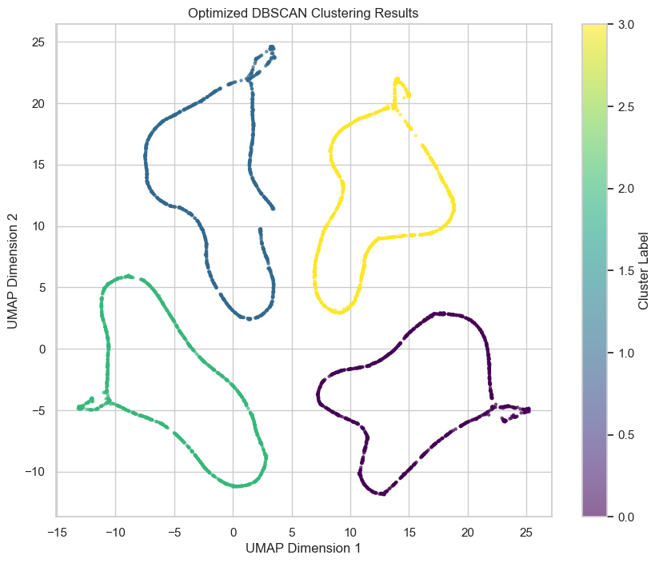

```
Submission file saved to: ../models/task2/submission_20241017_043648_umap_nn20_md0.3_dbscan_eps3.20_ms10_sil0.4158.csv
```

```python
# Retrieve the best trial's parameters
best_params = best_trial.params

# Apply UMAP and DBSCAN with the best hyperparameters
umap_reducer_best = umap.UMAP(
    n_neighbors=best_params['n_neighbors'],
    min_dist=best_params['min_dist'],
    n_components=2,
    random_state=42
)
X_umap_best = umap_reducer_best.fit_transform(sorted_df.iloc[:, 1:])

dbscan_best = DBSCAN(
    eps=best_params['eps'],
    min_samples=best_params['min_samples']
)
cluster_labels_best = dbscan_best.fit_predict(X_umap_best)

# Calculate the silhouette score
sil_score_best = silhouette_score(X_umap_best, cluster_labels_best)
print(f"Best Silhouette Score: {sil_score_best:.4f}")

# Visualize the best clustering
plt.figure(figsize=(10, 8))
plt.scatter(X_umap_best[:, 0], X_umap_best[:, 1], c=cluster_labels_best, cmap='viridis', s=5, alpha=0.6)
plt.title('Optimized DBSCAN Clustering Results')
plt.xlabel('UMAP Dimension 1')
plt.ylabel('UMAP Dimension 2')
plt.colorbar(label='Cluster Label')
plt.show()

# Generate the final submission file
final_submission_path = generate_submission(
    cluster_labels=cluster_labels_best,
    ids=sorted_df['ID'],
    hyperparams=best_params,
    silhouette_score=sil_score_best,
    model_save_path=model_path_2
)
```

## Discussion Questions

### Dimensionality Reduction

**Question**: Which dimensionality reduction methods helped you determine the correct number of clusters? Why did some methods work better than others? Explain the differences between PCA, t-SNE, and UMAP.

**Answer**: Figuring out in the EDA that we were dealing with image data, it became clear that UMAP was the most promising feature reduction technique. Betting on the fact that we were dealing with non-linear data (typical for images), and knowing that UMAP is superior in handling spatial context and internal geometry, whereas t-SNE distorts global relationships, I did not care to explore what I considered dead-ends.

### Clustering Approach

**Question**: Which clustering algorithm and hyperparameters did you use? Discuss the differences between algorithms like KMeans and DBSCAN.

**Answer**: I plotted some UMAP feature reductions with different hyperparameters, and from those plots it was clear that the clusterings were not spherical, which is a precondition for KMeans to work effectively. Thus I went for DBScan which can handle clusters of arbitrary shapes, which was what I was observing.

### Server Locations

**Question**: Identify the server locations. List the specific facilities in Trondheim and explain how you deduced their locations.

**Answer**: By sorting the columns of the data and then visualizing each row as a 128*128 image, I was able to see the map data. I discovered that there was not a new image for every row of the data, but that they were variations of each other. After running the Optuna trials, we found that the best trial generated a prediction of 4 clusters. Looking at the images, we can identify these server locations as:

- Pirbadet (Sample 13, ...)
- Trondheim Spektrum (Sample 0, ...)
- IKEA Leangen (Sample 1, ...)
- Studentersamfundet (Sample 1010, ...)

### Data Type Analysis

**Question**: What is the hidden data type in the dataset? How does this information influence feature extraction for clustering? Can it explain why some dimensionality reduction algorithms are more effective?

**Answer**: The hidden data type is greyscale pixel values, and this has influenced the decisions we made regarding choosing UMAP for feature reduction.